# OpenAlexAPI_v01

2023-01-18

```
## [1] "https://api.openalex.org/works?filter=title.search%3Aartificial%20intelligence%7Cmachine%20learning%7Cdeep%20learning%7Cwater%20resources%2Ccited_by_count%3A%3E50%2Cfrom_publication_date%3A2000-01-01%2Cto_publication_date%3A2021-12-31&sort=cited_by_count%3Adesc"
```

```
## Requesting url: https://api.openalex.org/works?filter=title.search%3Aartificial%20intelligence%7Cmachine%20learning%7Cdeep%20learning%7Cwater%20resources%2Ccited_by_count%3A%3E50%2Cfrom_publication_date%3A2000-01-01%2Cto_publication_date%3A2021-12-31&sort=cited_by_count%3Adesc
```

```
## About to get a total of 65 pages of results with a total of 12805 records.
```

Paso 1: Formato de tabla (faltan estilos)

| short_id | display_name | first_author | last_author | so | url | is_oa | top_concepts |
| --- | --- | --- | --- | --- | --- | --- | --- |
| W2194775991 | Deep Residual Learning for Image Recognition | Kaiming He | Jian Sun | Computer Vision and Pattern Recognition | NA | FALSE | Residual, Computer science, Artificial intelligence, Coco, Object detection, Deep learning |
| W2919115771 | Deep learning | Yann LeCun | Geoffrey E. Hinton | Nature | NA | FALSE | Computer science, Deep learning, Artificial intelligence, Abstraction, Representation (politics), Layer (electronics) |
| W2145339207 | Human-level control through deep reinforcement learning | Volodymyr Mnih | Demis Hassabis | Nature | NA | FALSE | Reinforcement learning, Artificial intelligence, Computer science, Variety (cybernetics), Set (abstract data type), Artificial neural network |
| W2136922672 | A Fast Learning Algorithm for Deep Belief Nets | Geoffrey E. Hinton | Yee Whye Teh | Neural Computation | NA | FALSE | Associative property, Computer science, Prior probability, Generative model, Discriminative model, Content-addressable memory |
| W2157331557 | Learning Phrase Representations using RNN Encoder–Decoder for Statistical Machine Translation | Kyunghyun Cho | Yoshua Bengio | Cornell University - arXiv | http://arxiv.org/pdf/1406.1078 | TRUE | Decodes, Computer science, Encoder, Recurrent neural network, Machine translation, Phrase |
| W2076063813 | Deep learning in neural networks: An overview | Jürgen Schmidhuber |  | Neural Networks | NA | FALSE | Artificial intelligence, Deep learning, Computer science, Backpropagation, Artificial neural network, Machine learning |

Paso 2: EDA (Exploratory Data Analysis) : Exploratory Analyses

```r
test %>%
  show_works() %>%
  summary()
```

```
##    short_id         display_name
##  Length:6           Length:6
##  Class :character   Class :character
##  Mode  :character   Mode  :character
##
##
##
##  first_author.Length  first_author.Class  first_author.Mode
##  1          -none-     character
##  1          -none-     character
##  1          -none-     character
##  1          -none-     character
##  1          -none-     character
##  1          -none-     character
##  last_author.Length  last_author.Class  last_author.Mode      so
##  1          -none-     character                         Length:6
##  1          -none-     character                         Class :character
##  1          -none-     character                         Mode  :character
##  1          -none-     character
##  1          -none-     character
##  0          -none-     character
##      url              is_oa         top_concepts
##  Length:6           Mode :logical   Length:6
##  Class :character   FALSE:5         Class :character
##  Mode  :character   TRUE :1         Mode  :character
##
##
##
```

```r
test %>%
  show_works() %>%
  head(5)
```

```
## # A tibble: 5 × 8
##   short_id    display_name             first…¹ last_…² so    url   is_oa top_c…³
##   <chr>       <chr>                    <list>  <list>  <chr> <chr> <lgl> <chr>
## 1 W2194775991 Deep Residual Learning … <chr>   <chr>   Comp… <NA>  FALSE Residu…
## 2 W2919115771 Deep learning            <chr>   <chr>   Natu… <NA>  FALSE Comput…
## 3 W2145339207 Human-level control thr… <chr>   <chr>   Natu… <NA>  FALSE Reinfo…
## 4 W2136922672 A Fast Learning Algorit… <chr>   <chr>   Neur… <NA>  FALSE Associ…
## 5 W2157331557 Learning Phrase Represe… <chr>   <chr>   Corn… http… TRUE  Decode…
## # … with abbreviated variable names ¹first_author, ²last_author, ³top_concepts
```

```r
test %>%
  show_works() %>%
  str()
```

```
## tibble [6 × 8] (S3: tbl_df/tbl/data.frame)
##  $ short_id    : chr [1:6] "W2194775991" "W2919115771" "W2145339207" "W2136922672" ...
##  $ display_name: chr [1:6] "Deep Residual Learning for Image Recognition" "Deep learning" "Human-level control through deep reinforcement learning" "A Fast Learning Algorithm for Deep Belief Nets" ...
##  $ first_author:List of 6
##   ..$ : chr "Kaiming He"
##   ..$ : chr "Yann LeCun"
##   ..$ : chr "Volodymyr Mnih"
##   ..$ : chr "Geoffrey E. Hinton"
##   ..$ : chr "Kyunghyun Cho"
##   ..$ : chr "Jürgen Schmidhuber"
##  $ last_author :List of 6
##   ..$ : chr "Jian Sun"
##   ..$ : chr "Geoffrey E. Hinton"
##   ..$ : chr "Demis Hassabis"
##   ..$ : chr "Yee Whye Teh"
##   ..$ : chr "Yoshua Bengio"
##   ..$ : chr(0)
##  $ so          : chr [1:6] "Computer Vision and Pattern Recognition" "Nature" "Nature" "Neural Computation" ...
##  $ url         : chr [1:6] NA NA NA NA ...
##  $ is_oa       : logi [1:6] FALSE FALSE FALSE FALSE TRUE FALSE
##  $ top_concepts: chr [1:6] "Residual, Computer science, Artificial intelligence, Coco, Object detection, Deep learning" "Computer science, Deep learning, Artificial intelligence, Abstraction, Representation (politics), Layer (electronics)" "Reinforcement learning, Artificial intelligence, Compute…
```

```r
test %>%
  show_works() %>%
  glimpse()
```

```
## Rows: 6
## Columns: 8
## $ short_id     <chr> "W2194775991", "W2919115771", "W2145339207", "W2136922672…
## $ display_name <chr> "Deep Residual Learning for Image Recognition", "Deep lea…
## $ first_author <list> "Kaiming He", "Yann LeCun", "Volodymyr Mnih", "Geoffrey …
## $ last_author  <list> "Jian Sun", "Geoffrey E. Hinton", "Demis Hassabis", "Yee…
## $ so           <chr> "Computer Vision and Pattern Recognition", "Nature", "Nat…
## $ url          <chr> NA, NA, NA, NA, "http://arxiv.org/pdf/1406.1078", NA
## $ is_oa        <lgl> FALSE, FALSE, FALSE, FALSE, TRUE, FALSE
## $ top_concepts <chr> "Residual, Computer science, Artificial intelligence, Coc…
```

Paso 3: EDA (Exploratory Data Analysis) : Data Analyses

Goal: track the popularity of Computer science concepts over time

```
## label_key: display_name
```

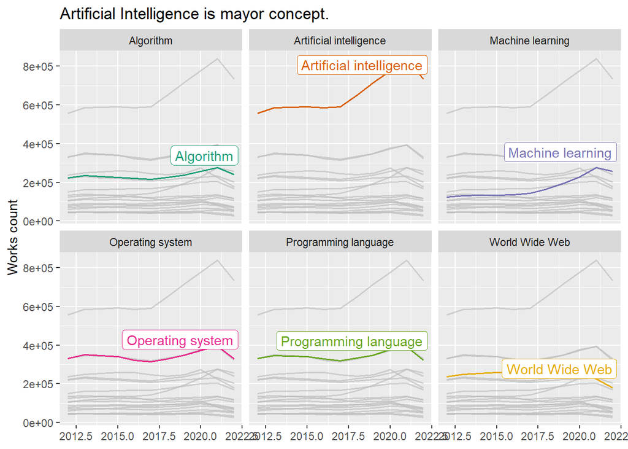

```r
#Goal: track the popularity of Computer science concepts over time.
#We first download the records of all level-1 concepts/keywords that concern over one million works:
#Concepts: https://github.com/massimoaria/openalexR/commit/2a8da4303447529210ba9b941a5da0cadbe15531

concept_df <- oa_fetch(
  entity = "concepts",
  level = 1,
  ancestors.id = "https://openalex.org/C41008148", #Computer Science
  works_count = ">1000000"
)

concept_df %>%
  select(display_name, counts_by_year) %>%
  tidyr::unnest(counts_by_year) %>%
  filter(year < 2023) %>%
  ggplot() +
  aes(x = year, y = works_count, color = display_name) +
  facet_wrap(~display_name) +
  geom_line(linewidth = 0.7) +
  scale_color_brewer(palette = "Dark2") +
  labs(
    x = NULL, y = "Works count",
    title = "Artificial Intelligence is mayor concept."
  ) +
  guides(color = "none") +
  gghighlight(
    max(works_count) > 244000,
    label_params = list(nudge_y = 10^5, segment.color = NA)
  )
```

Goal: Rank institutions in China by total number of citations. We want download all records regarding chinnese institutions (country_code:cn) that are classified as educational (type:education). Again, we check how many records match the query then download the collection

```r
china_insts <- oa_fetch(
  entity = "institutions",
  country_code = "cn",
  type = "education",
  verbose = TRUE
)
```

```
## [1] "https://api.openalex.org/institutions?filter=country_code%3Acn%2Ctype%3Aeducation"
```

```
## Requesting url: https://api.openalex.org/institutions?filter=country_code%3Acn%2Ctype%3Aeducation
```

```
## About to get a total of 6 pages of results with a total of 1098 records.
```

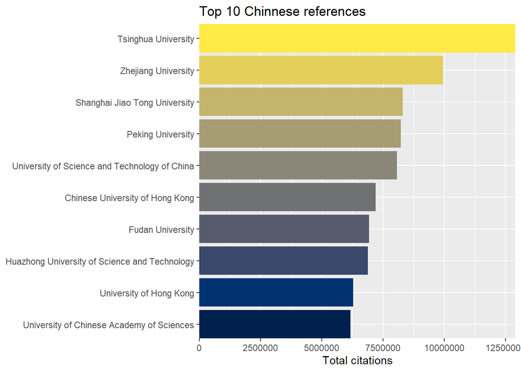

```r
china_insts %>%
  slice_max(cited_by_count, n = 10) %>%
  mutate(display_name = forcats::fct_reorder(display_name, cited_by_count)) %>%
  ggplot() +
  aes(x = cited_by_count, y = display_name, fill = display_name) +
  geom_col() +
  scale_fill_viridis_d(option = "E") +
  guides(fill = "none") +
  labs(
    x = "Total citations", y = NULL,
    title = "Top 10 Chinnese references"
  ) +
  coord_cartesian(expand = FALSE)
```

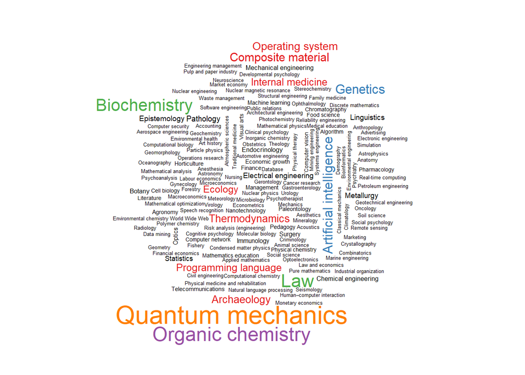

```r
concept_cloud <- china_insts %>%
  select(inst_id = id, x_concepts) %>%
  tidyr::unnest(x_concepts) %>%
  filter(level == 1) %>%
  select(display_name, score) %>%
  group_by(display_name) %>%
  summarise(score = sum(score))

pal <- c("black", scales::brewer_pal(palette = "Set1")(5))
set.seed(1)
wordcloud::wordcloud(
  concept_cloud$display_name,
  concept_cloud$score,
  scale = c(2, .4),
  colors = pal
)
```

```r
# Carga tibble de conceptos
load(file='~/doctorado/articulo/OpenAlexAPI/data/concept_abbrev.rda')
```

```r
jours <- oa_fetch(
  entity = "venues",
  works_count = ">500000",
  verbose = TRUE
) %>%
  filter(publisher != "Elsevier"|is.na(publisher)) %>%
  distinct(display_name, .keep_all = TRUE) %>%
  select(jour = display_name, x_concepts) %>%
  tidyr::unnest(x_concepts) %>%
  filter(level == 0) %>%
  left_join(concept_abbrev, by = c("id", "display_name")) %>%
  mutate(abbreviation = gsub(" ", "<br>", abbreviation)) %>%
  tidyr::complete(jour, abbreviation, fill = list(score = 0)) %>%
  group_by(jour) %>%
  mutate(
    color = if_else(score > 10, "#1A1A1A", "#D9D9D9"), # CCCCCC
    label = paste0("<span style='color:", color, "'>", abbreviation, "</span>"))
```

```
## [1] "https://api.openalex.org/venues?filter=works_count%3A%3E500000"
```

```
## Requesting url: https://api.openalex.org/venues?filter=works_count%3A%3E500000
```

```
## About to get a total of 1 pages of results with a total of 14 records.
```

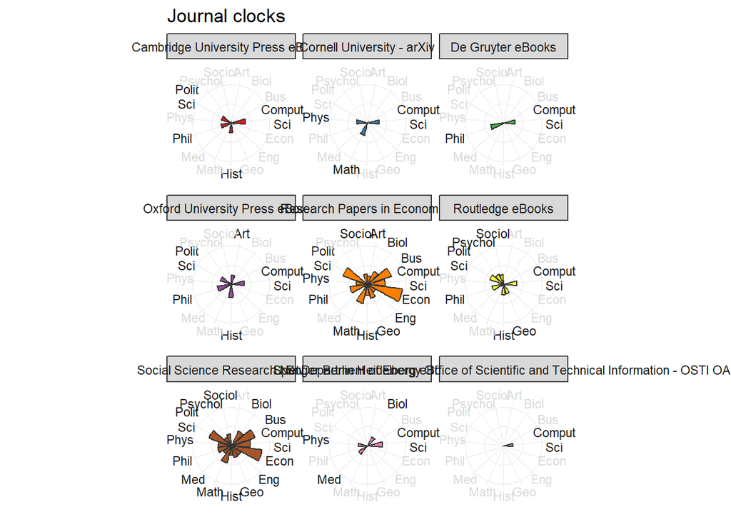

```r
jours %>%
  ggplot() +
  aes(fill = jour, y = score, x = abbreviation, group = jour) +
  facet_wrap(~jour) +
  geom_hline(yintercept = c(45, 90), colour = "grey90", linewidth = 0.2) +
  geom_segment(
    aes(x = abbreviation, xend = abbreviation, y = 0, yend = 100),
    color = "grey95"
  ) +
  geom_col(color = "grey20") +
  coord_polar(clip = "off") +
  theme_bw() +
  theme(
    plot.background = element_rect(fill = "transparent", colour = NA),
    panel.background = element_rect(fill = "transparent", colour = NA),
    panel.grid = element_blank(),
    panel.border = element_blank(),
    axis.text = element_blank(),
    axis.ticks.y = element_blank()
  ) +
  ggtext::geom_richtext(
    aes(y = 120, label = label),
    fill = NA, label.color = NA, size = 3
  ) +
  scale_fill_brewer(palette = "Set1") +
  guides(fill = "none") +
  labs(y = NULL, x = NULL, title = "Journal clocks")
```

Goal: Snowball search The user can also perform snowballing with oa_snowball. Snowballing is a literature search technique where the researcher starts with a set of articles and find articles that cite or were cited by the original set. oa_snowball returns a list of 2 elements: nodes and edges. Similar to oa_fetch, oa_snowball finds and returns information on a core set of articles satisfying certain criteria, but, unlike oa_fetch, it also returns information the articles that cite and are cited by this core set.

```r
snowball_docs <- oa_snowball(
  identifier = c("W1964141474", "W1963991285"),
  verbose = TRUE
)
```

```
## [1] "https://api.openalex.org/works?filter=cites%3AW1964141474%7CW1963991285"
```

```
## Requesting url: https://api.openalex.org/works?filter=cites%3AW1964141474%7CW1963991285
```

```
## About to get a total of 3 pages of results with a total of 467 records.
```

```
## [1] "https://api.openalex.org/works?filter=openalex_id%3AW1964141474%7CW1963991285"
```

```
## Requesting url: https://api.openalex.org/works?filter=openalex_id%3AW1964141474%7CW1963991285
```

```
## About to get a total of 1 pages of results with a total of 2 records.
```

```
## [1] "https://api.openalex.org/works?filter=openalex_id%3Ahttps%3A%2F%2Fopenalex.org%2FW1965248225%7Chttps%3A%2F%2Fopenalex.org%2FW1965508252%7Chttps%3A%2F%2Fopenalex.org%2FW1967629764%7Chttps%3A%2F%2Fopenalex.org%2FW1967675906%7Chttps%3A%2F%2Fopenalex.org%2FW1975558010%7Chttps%3A%2F%2Fopenalex.or…
```

```
## Requesting url: https://api.openalex.org/works?filter=openalex_id%3Ahttps%3A%2F%2Fopenalex.org%2FW1965248225%7Chttps%3A%2F%2Fopenalex.org%2FW1965508252%7Chttps%3A%2F%2Fopenalex.org%2FW1967629764%7Chttps%3A%2F%2Fopenalex.org%2FW1967675906%7Chttps%3A%2F%2Fopenalex.org%2FW1975558010%7Chttps%3A%2F%2F…
```

```
## About to get a total of 1 pages of results with a total of 50 records.
```

```
## [1] "https://api.openalex.org/works?filter=openalex_id%3Ahttps%3A%2F%2Fopenalex.org%2FW2038028083%7Chttps%3A%2F%2Fopenalex.org%2FW2041541331%7Chttps%3A%2F%2Fopenalex.org%2FW2041627495%7Chttps%3A%2F%2Fopenalex.org%2FW2050045067%7Chttps%3A%2F%2Fopenalex.org%2FW2056486423%7Chttps%3A%2F%2Fopenalex.or…
```

```
## Requesting url: https://api.openalex.org/works?filter=openalex_id%3Ahttps%3A%2F%2Fopenalex.org%2FW2038028083%7Chttps%3A%2F%2Fopenalex.org%2FW2041541331%7Chttps%3A%2F%2Fopenalex.org%2FW2041627495%7Chttps%3A%2F%2Fopenalex.org%2FW2050045067%7Chttps%3A%2F%2Fopenalex.org%2FW2056486423%7Chttps%3A%2F%2F…
```

```
## About to get a total of 1 pages of results with a total of 37 records.
```

```r
#ggraph(graph = as_tbl_graph(snowball_docs), layout = "stress") +
#  geom_edge_link(aes(alpha = after_stat(index)), show.legend = FALSE) +
#  geom_node_point(aes(fill = oa_input, size = cited_by_count), shape = 21) +
#  geom_node_label(aes(filter = oa_input, label = id), nudge_y = 0.2, size = 3) +
#  scale_edge_width(range = c(0.1, 1.5), guide = "none") +
#  scale_size(range = c(3, 10), guide = "none") +
#  scale_fill_manual(values = c("#1A5878", "#C44237"), na.value = "grey", name = "") +
#  theme_graph() +
#  theme(legend.position = "bottom") +
#  guides(fill = "none")
```